# Week 03

Quantitative data

Dr. Peng Zhao

2020-09-24

## Q & A

Q1. Can the solutions for the exercises be provided?

A1. Yes. The solutions for the exercises of Week 01 and Week 02 are already uploaded to the Learning Mall. Note that these solutions are only for reference. Feel free to carry out your own solutions. In the future, the solutions for reference will be uploaded one week after the exercises are released.

Q2. Can we have a specific training for statistical software such as R?

A1. Not in this module. We do not have enough time. Note that we have only 26 hours in total for lectures/tutorials. The good news is that there are some external trainings available. For example, see the [XJTLU Library Event Calendar](https://libcal.lib.xjtlu.edu.cn/).

- R Workshop Series 1: Data Analysis with R Language - An Introduction. Dr. Yi Zou. November 18, 14:00, CB455
- R Workshop Series 2: Modern Statistical Graphs with R. Dr. Peng Zhao. November 25, 14:00 CB455

Other trainings, if any, will be announced on the Learning Mall.

## Ice breaking

- Role play: *The Manga Guide to Statistics*: Numerical data
- Keywords: histogram (Sturges’ Rule), mean, median, standard deviation.

## Objectives

1. Understand how to measure numerical data.
2. Use parameters/statistics to describe numerical data.
3. Use histograms, box graphs, density curve for presenting numericla data.

## Measures of the Center

### Mean

- Arithmetic Mean: $\mu = \Sigma x_i / N$, $\bar x = \Sigma x_i / n$.

Demo:

The daily temperatures for last week were $t_1 = 27, t_2 = 26, t_3 = 30, t_4 = 27, t_5 = 29, t_6 = 30, t_7 = 25 ^\circ$C. The mean temperature of last week was $\bar t = \Sigma t_i / n$ $^\circ$C.

```r
(27+ 26 + 30 + 27 + 29 + 30 + 25) / 7
```

```
## [1] 27.71429
```

```r
tc <- c(27, 26, 30, 27, 29, 30, 25)
sum(tc)/length(tc)
```

```
## [1] 27.71429
```

```r
mean(tc)
```

```
## [1] 27.71429
```

- If $y_i = x_i + c$, then $\bar y = \bar x + c$. This is called a translated sample.

Demo:

Calculate the mean daily temperature of last week in Kelvin, $[K] = [^\circ \text C] + 273$.

```r
mean(tc + 273)
```

```
## [1] 300.7143
```

```r
mean(tc) + 273
```

```
## [1] 300.7143
```

```r
mean(tc + 273) == mean(tc) + 273
```

```
## [1] TRUE
```

- If $y_i = cx_i$, then $\bar y = c \bar x$. This is called a scaled sample.

Demo:

The morning wind speed in the air quality dataset (airquality.csv) is given in mile per hour. Calculate the mean wind speed in meter per second.

```r
df_aq <- read.csv('data/airquality.csv')
mean(df_aq$Wind * 1.6 * 1000 / 3600)
```

```
## [1] 4.425563
```

```r
mean(df_aq$Wind) * 1.6 * 1000 / 3600
```

```
## [1] 4.425563
```

- If $y_i = c_1 x_i + c_2$, then $\bar y = c_1 \bar x + c_2$. This is called a transformed sample.

Demo:

Calculate the mean daily temperature of last week in degree Fahrenheit, $[^\circ \text F] = [^\circ \text C] \times 9/5 + 32$.

```r
mean(tc * 9 / 5 + 32)
```

```
## [1] 81.88571
```

```r
mean(tc) * 9 / 5 + 32
```

```
## [1] 81.88571
```

- Geometric Mean: $G=\sqrt[n] {\Pi x_i}$

Demo:

An orange tree yielded 100 oranges in 2016, then 180, 210 and 300 in 2017, 2018, and 2019, respectively, which means the yield increased by 80%, 17%, and 43%, respectively. What is the mean annual growth rate?

```r
increase <- c(0.8, 0.17, 0.43)
r_annual <- increase + 1
r_gm <- prod(r_annual) ^ (1/3)
100 * (r_gm) ^3
```

```
## [1] 301.158
```

The arithmetic mean of the growth rate makes no sense in this case.

```r
r_am <- mean(increase) + 1
100 * r_am ^3 # This is meaningless
```

```
## [1] 315.4963
```

- Harmonic Mean: $H = n/\Sigma \frac{1}{x_i}$

Demo:

Tom lives at Wenxing Square. He takes part in ENV203. One day he walked from Wenxing Square to ES209 at a speed of 8 km/h. After the class, he went back at a speed of 10 km/h. What was the mean speed?

```r
sp <- c(8, 10)
sp_hm <- 1/mean(1/sp)
sp_hm
```

```
## [1] 8.888889
```

The harmonic mean is meaningful. Suppose the distance between Wenxing Square and ES209 is 1.1 km, then we can calculate the time Tom spent:

```r
1.1 * 2 / sp_hm
```

```
## [1] 0.2475
```

Let’s calculate the time separately:

```r
1.1 / 8 + 1.1 / 10
```

```
## [1] 0.2475
```

While the arithmetic mean is meaningless in this case.

```r
mean(sp)
```

```
## [1] 9
```

### Median

**Median:**

Middle value of an ordered set. Also called $Q_2$ and $P_{50}$.

- If *n* is odd, the median is the $(n+1)/2$ -th largest observation
- If *n* is even, the median is the mean of the $n/2$ -th and the $(n+1)/2$ -th largest observation

Demo:

1. The ENV206 students wanted to know the surface water temperature on the Xishan Island. They randomly selected four locations at 11:59 PM on 1/1/2018, and got the following temperatures: 3.0, 2.1, 3.0 and 24 $^\circ$C. Find the measures of the center with the mean and median.

```r
t <- c(3.0, 2.1, 3.0, 24)
mean(t)
```

```
## [1] 8.025
```

```r
median(t)
```

```
## [1] 3
```

Demo:

I was in the XJTLU souvenir shop. I was going to buy one T-shirt for ENV203 students as an award of the best role-play. I didn’t know who would win. What size should I buy?

Mean is the best way to estimate a subject of a population, while the median is the safest. However, both are insufficient and unsatisfactory because of the lack of the variance.

## Measures of Spread

### Generic Measure

- Range: $x_\text{max} - x_\text{min}$

Demo:

The range of the ozone concentration in the air quality dataset.

```r
min(df_aq$Ozone, na.rm = TRUE)
```

```
## [1] 1
```

```r
max(df_aq$Ozone, na.rm = TRUE)
```

```
## [1] 168
```

```r
range(df_aq$Ozone, na.rm = TRUE)
```

```
## [1]   1 168
```

### Measures Paired with the Arithmetic Mean

- Variance: for a population, $\sigma^2 = \frac{\Sigma (x_i - \mu)^2}{N}$; for a sample, $s^2 = \frac{\Sigma (x_i - \bar x)^2}{n-1}$
- Standard deviation: $\sigma$, $s$
- Coefficient of variation: $c_v = \sigma / \mu$, $c_v = s / \bar x$

Demo:

- Calculate the variance, standard deviation, and coefficient of variation of the height of ENV203 students.
- Calculate the variance, standard deviation, and coefficient of variation of the TCE concentration before and after remediation, respectively.

```r
env203 <- read.csv("data/students203.csv", encoding = "UTF-8")
h <- env203$Height
mu_h <- mean(h)
mu_h
```

```
## [1] 168.22
```

```r
h_mu_h <- h - mu_h  # h - mu_h
h_mu_h
```

```
##  [1]  -0.22 -18.22  -5.22 -10.22   6.78   8.78   4.78   7.78   1.78  17.78
## [11]   1.78   5.78   4.78  -5.22   6.78 -18.22   1.78  -8.22   1.78   3.78
## [21]   8.78   6.78  -0.22  -2.22  -7.22  -5.22   0.78  -3.22   5.78  -2.22
## [31]   1.78  -3.22 -13.22   5.78  -3.22  -3.22  -0.22  -3.22  -3.22 -10.22
## [41]  -1.22  -0.22   4.78  13.78  -5.22  -6.22  -0.22   1.78   6.78   7.78
```

```r
h_mu_h ^ 2
```

```
##  [1]   0.0484 331.9684  27.2484 104.4484  45.9684  77.0884  22.8484  60.5284
##  [9]   3.1684 316.1284   3.1684  33.4084  22.8484  27.2484  45.9684 331.9684
## [17]   3.1684  67.5684   3.1684  14.2884  77.0884  45.9684   0.0484   4.9284
## [25]  52.1284  27.2484   0.6084  10.3684  33.4084   4.9284   3.1684  10.3684
## [33] 174.7684  33.4084  10.3684  10.3684   0.0484  10.3684  10.3684 104.4484
## [41]   1.4884   0.0484  22.8484 189.8884  27.2484  38.6884   0.0484   3.1684
## [49]  45.9684  60.5284
```

```r
sum(h_mu_h ^ 2)
```

```
## [1] 2556.58
```

```r
N <- length(h)
sum(h_mu_h ^ 2)
```

```
## [1] 2556.58
```

```r
sum(h_mu_h ^ 2) / N
```

```
## [1] 51.1316
```

```r
var(h)
```

```
## [1] 52.1751
```

```r
sum(h_mu_h ^ 2) / (N - 1)
```

```
## [1] 52.1751
```

```r
var(env203$Height) * (N - 1) / N
```

```
## [1] 51.1316
```

```r
sqrt(sum(h_mu_h ^ 2) / N)
```

```
## [1] 7.150636
```

```r
sd(h)
```

```
## [1] 7.223233
```

```r
sd(h) * sqrt(N - 1) / sqrt(N)
```

```
## [1] 7.150636
```

### Measures Paired with the Median

- Percentiles (or quartiles)
  - The *p*-th percentile is the value $V_p$ such that *p*% of the sample points are less than or equal to $V_p$.
  - Three quartiles: $Q_1 = P_{25}$, $Q_2 = P_{50} = \mathrm {median}$, $Q_3 = P_{75}$.
  - Interquartile range: $\text{IQR} = Q_3 − Q_1 = P_{75} − P_{25}$

If the 25th percentile (or the first quartile) of a dataset is 667 grams, then 25% of all data points are less than or equal to 667 grams.

Demo:

1. The ENV206 students wanted to know the surface water temperature on the Xishan Island. They randomly selected four locations at 11:59 PM on 1/1/2018, and got the following temperatures: 3.0, 2.1, 3.0 and 24 $^\circ$C. Find the measures of spread with the variance, median, minimum, $Q_1, Q_3$, maximum, IQR.
2. ENV Students data. Find the measures of spread paired with the median of the studnets’ height. What are the values of them for male and female, respectively?

```r
t <- c(3.0, 2.1, 3.0, 24)
var(t)
```

```
## [1] 113.6025
```

```r
median(t)
```

```
## [1] 3
```

```r
min(t)
```

```
## [1] 2.1
```

```r
max(t)
```

```
## [1] 24
```

```r
Q1 <- quantile(t, 0.25)
Q1
```

```
##   25%
## 2.775
```

```r
Q3 <- quantile(t, 0.75)
Q3
```

```
##  75%
## 8.25
```

```r
quantile(t, probs = c(0.25, 0.75))
```

```
##   25%   75%
## 2.775 8.250
```

```r
Q3 - Q1
```

```
##   75%
## 5.475
```

```r
IQR(t)
```

```
## [1] 5.475
```

```r
summary(t)
```

```
##    Min. 1st Qu.  Median    Mean 3rd Qu.    Max.
##   2.100   2.775   3.000   8.025   8.250  24.000
```

```r
summary(env203$Height)
```

```
##    Min. 1st Qu.  Median    Mean 3rd Qu.    Max.
##   150.0   165.0   168.0   168.2   173.8   186.0
```

```r
male_index <- env203$Gender == "Male"
h_male <- env203$Height[male_index]
quantile(h_male, probs = c(0.25, 0.5, 0.75))
```

```
##    25%    50%    75%
## 174.75 175.50 177.00
```

```r
female_index <- env203$Gender == "Female"
h_female <- env203$Height[female_index]
quantile(h_female, probs = c(0.25, 0.5, 0.75))
```

```
## 25% 50% 75%
## 163 166 170
```

```r
tapply(env203$Height, env203$Gender, summary)
```

```
## $Female
##    Min. 1st Qu.  Median    Mean 3rd Qu.    Max.
##   150.0   163.0   166.0   165.7   170.0   175.0
##
## $Male
##    Min. 1st Qu.  Median    Mean 3rd Qu.    Max.
##   170.0   174.8   175.5   176.3   177.0   186.0
```

## Measures of Shape

### Skewness

Central Symmetry:

- No skew
- Left skew
- Right skew

### Kurtosis

Peakedness:

- Leptokurtic distributions are tall and slender.
- Platykurtic distributions are broad and flat.

## Graphs with quantitative data

We will use the height of ENV203 students dataset as demonstrations.

### Strip chart

A strip chart display one dimensional scatter plots (or dot plots) of the given data.

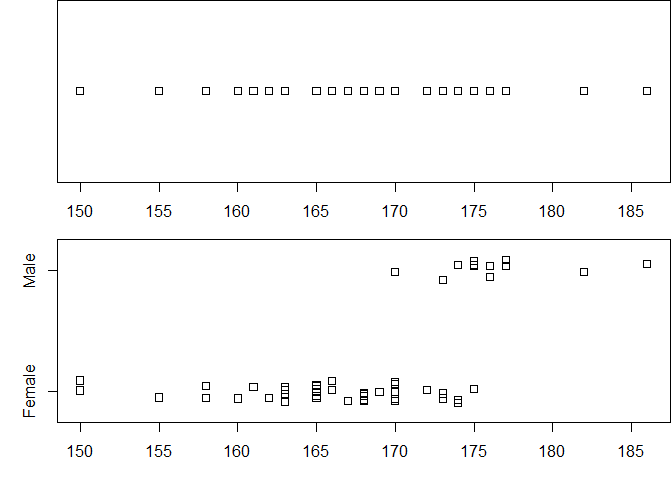

Strip chart of the height (cm) of ENV203 students

```r
par(mfrow = c(2,1), mar = c(3, 3, 0, 0.1))
stripchart(env203$Height)
stripchart(env203$Height ~ env203$Gender, method = "jitter")
```

### Histogram

A histogram displays numerical data by indicating the number of data points that lie within a range of values. These ranges of values are called classes or bins.

```r
h
```

```
##  [1] 168 150 163 158 175 177 173 176 170 186 170 174 173 163 175 150 170 160 170
## [20] 172 177 175 168 166 161 163 169 165 174 166 170 165 155 174 165 165 168 165
## [39] 165 158 167 168 173 182 163 162 168 170 175 176
```

```r
range(h)
```

```
## [1] 150 186
```

```r
h_breaks <- cut(h,
                breaks = c(150, 155, 160, 165, 170,
                           175, 180, 185, 190))
# or:
# h_breaks <- cut(h, breaks = seq(150, 190, 5))
h_breaks
```

```
##  [1] (165,170] <NA>      (160,165] (155,160] (170,175] (175,180] (170,175]
##  [8] (175,180] (165,170] (185,190] (165,170] (170,175] (170,175] (160,165]
## [15] (170,175] <NA>      (165,170] (155,160] (165,170] (170,175] (175,180]
## [22] (170,175] (165,170] (165,170] (160,165] (160,165] (165,170] (160,165]
## [29] (170,175] (165,170] (165,170] (160,165] (150,155] (170,175] (160,165]
## [36] (160,165] (165,170] (160,165] (160,165] (155,160] (165,170] (165,170]
## [43] (170,175] (180,185] (160,165] (160,165] (165,170] (165,170] (170,175]
## [50] (175,180]
## 8 Levels: (150,155] (155,160] (160,165] (165,170] (170,175] ... (185,190]
```

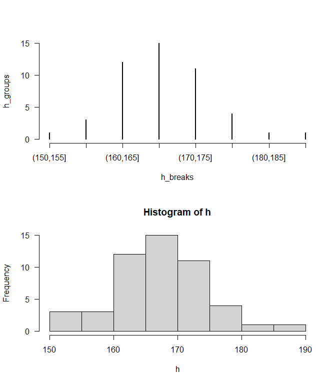

Histogram of height frequency of ENV203 students

```r
h_groups <- table(h_breaks)
par(mfrow = c(2,1), las = 1)
plot(h_groups)
ht <- hist(h)
```

```r
ht
```

```
## $breaks
## [1] 150 155 160 165 170 175 180 185 190
##
## $counts
## [1]  3  3 12 15 11  4  1  1
##
## $density
## [1] 0.012 0.012 0.048 0.060 0.044 0.016 0.004 0.004
##
## $mids
## [1] 152.5 157.5 162.5 167.5 172.5 177.5 182.5 187.5
##
## $xname
## [1] "h"
##
## $equidist
## [1] TRUE
##
## attr(,"class")
## [1] "histogram"
```

Question: How many bins should we use?

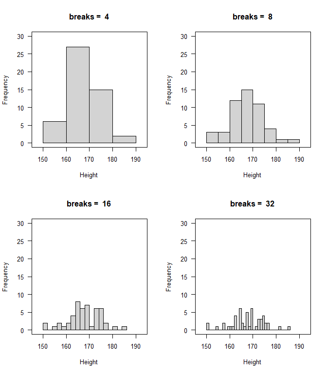

Different bins for histograms

Sturges’ Rule:

$$n_\text{class} = 1 + \frac{\log_{10}N}{\log_{10}2} = 1 + \log_2 N$$

```r
1 + log10(nrow(env203)) / log10(2)
```

```
## [1] 6.643856
```

```r
1 + log2(nrow(env203))
```

```
## [1] 6.643856
```

```r
nclass.Sturges(env203$Height)
```

```
## [1] 7
```

```r
nclass.scott(env203$Height)
```

```
## [1] 6
```

```r
nclass.FD(env203$Height)
```

```
## [1] 8
```

Question: The y-scales are different in these four sub-figures, why?

Convert the frequency to density:

```r
h_groups / 5 / 46
```

```
## h_breaks
##   (150,155]   (155,160]   (160,165]   (165,170]   (170,175]   (175,180]
## 0.004347826 0.013043478 0.052173913 0.065217391 0.047826087 0.017391304
##   (180,185]   (185,190]
## 0.004347826 0.004347826
```

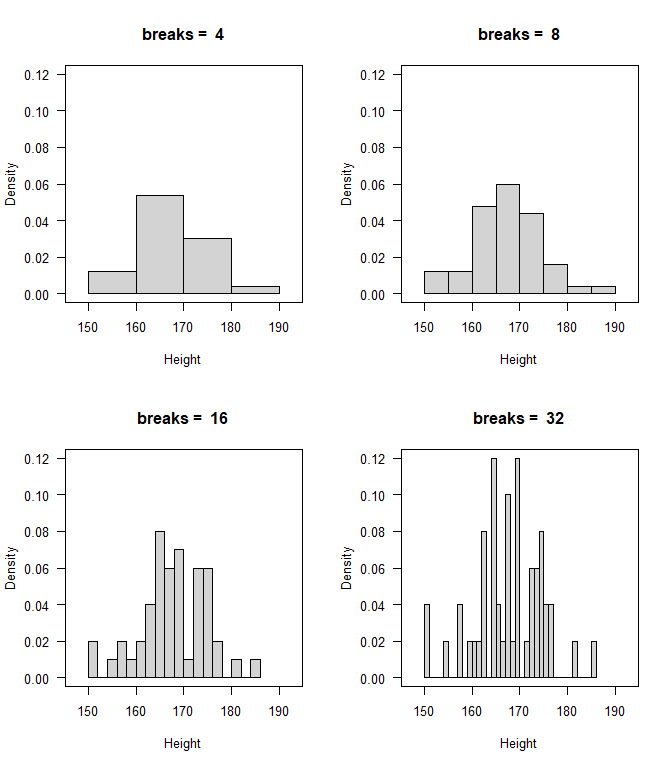

Histogram of the density

```r
par(mfrow= c(2, 2), las = 1)
for (bins in c(4, 8, 16, 32)){
  hist(env203$Height, breaks = bins, main = paste("breaks = ", bins),
       xlim = c(147, 193), ylim = c(0, 0.12),
       freq = FALSE, xlab = "Height")
  box()
}
```

Question: How many persons are there between 160 and 170 cm from the density histogram? And between 162 and 168?

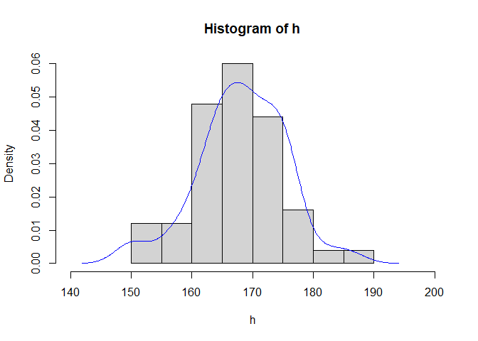

Histogram with the smooth density curve

```r
hist(h, freq = FALSE, xlim = c(140, 200))
lines(density(h), col = "blue")
```

### Box plot

Box plot is also called box-and-whisker plot.A box plot shows groups of numerical data through their quartiles, with lines extending from the boxes (whiskers) indicating variability outside the upper and lower quartiles.

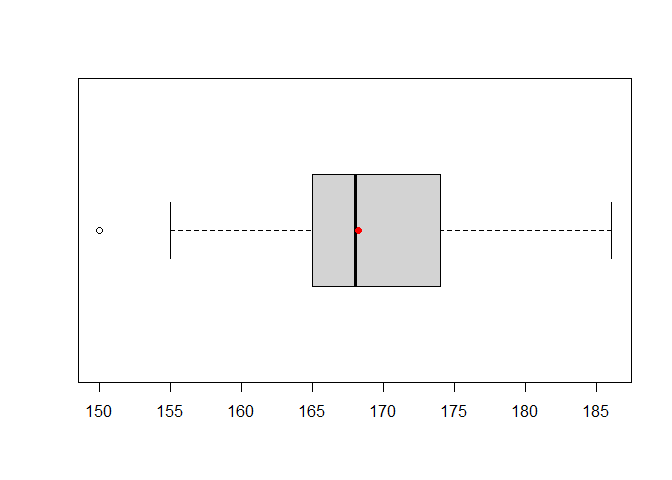

Box plot for the height

```r
boxplot(h, range = 1.5, horizontal = TRUE)
points(mean(h), 1, col = "red", pch = 16)
```

```r
summary(h)
```

```
##    Min. 1st Qu.  Median    Mean 3rd Qu.    Max.
##   150.0   165.0   168.0   168.2   173.8   186.0
```

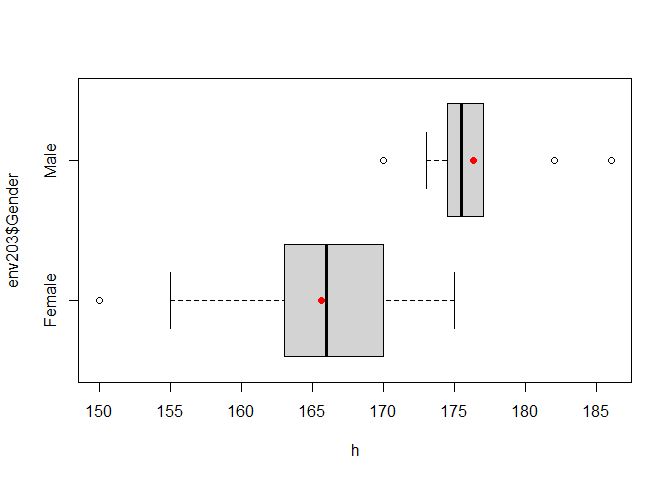

Box plots for the height grouped with the genders

```r
boxplot(h ~ env203$Gender, horizontal = TRUE)
points(tapply(h, env203$Gender, mean), 1:2, col = "red", pch = 16)
```

```r
tapply(h, env203$Gender, summary)
```

```
## $Female
##    Min. 1st Qu.  Median    Mean 3rd Qu.    Max.
##   150.0   163.0   166.0   165.7   170.0   175.0
##
## $Male
##    Min. 1st Qu.  Median    Mean 3rd Qu.    Max.
##   170.0   174.8   175.5   176.3   177.0   186.0
```

### Violin plot

A violin Plot is a combination of a box plot and a density plot that is rotated and placed on each side, to show the distribution shape of the data. The white dot in the middle is the median value and the thick black bar in the centre represents the interquartile range.

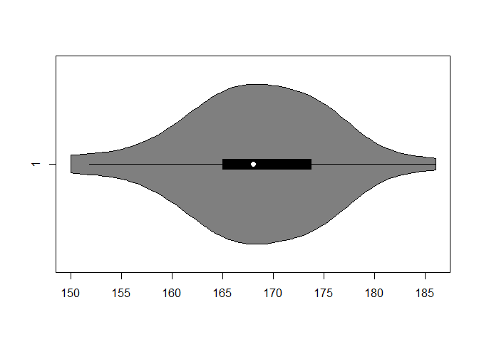

```r
library(vioplot)
vioplot(h, horizontal = TRUE)
```

If you have problems with installing the viplot package, you could plot a violin plot with ggplot2:

```r
library(ggplot2)
env203$All <- "All"
ggplot(env203, aes(x = All, y = Height)) +
  geom_violin() +
  geom_boxplot(width = 0.1) +
  coord_flip()
```

### Comparison of strip chart, histogram, box plot, violin plot

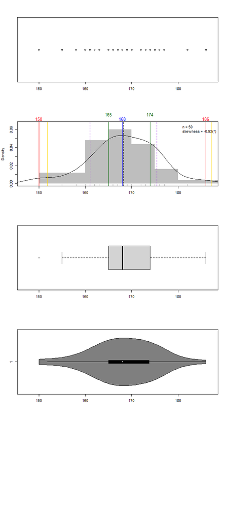

Comparison of strip chart, histogram, box plot, violin plot

## Assignments

- Read: *Arithmetic Versus Geometric Means for Environmental Concentration Data*
- Read: *A Beginner’s Guide to R* Chapter 7
- Read: *Measures of Shape Skewness and Kurtosis*
- Role play by a randomly chosen group: *The Manga Guide to Statistics*: Probability

## Exercises

**Ant line pits**

Larvae of the insect family, Myrmeleontidae, live in sandy soil and dig cone-shaped pits that trap ants and other prey that fall into them. These so-called ant lions stay in the soil with their heads just below the bottom of the pit and wait for unwary prey.

An ecology class determined the number of ant lion pits in a sample of 100 randomly selected 1 m$^2$ quadrats.

Results of ant lion pit survey.

| Pits/quadrat | Frequency |
| --- | --- |
| 0 | 5 |
| 1 | 15 |
| 2 | 23 |
| 3 | 21 |
| 4 | 17 |
| 5 | 11 |
| 6 | 5 |
| 7 | 2 |
| 8 | 1 |

1. Is the variable measured here discrete or continuous? Explain.
2. Calculate the sample mean and variance for these data.
3. Calculate the median and the range for these data.
4. Which pair of calculations (2) or (3) is more informative? Why?
5. Plot a histogram of the data.

**Smallmouth black bass**

The smallmouth black bass, *Micropterus dolomieu*, is a very popular game fish throughout the temperate zones of North America. In a Bassmaster tournament on the St. Lawrence River the following fish were caught and weighed to the nearest 10 grams.

1210, 1610, 1820, 1470, 1750, 1920, 1350, 1540, 1770, 1300, 1380, 1450, 1270, 2110, 2010

1. For this sample, find the mean, standard deviation. Also determine the median and the range. Which pair of statistics above is more informative? Provide a rationale for your answer.
2. Plot a histogram and a violin graph of the data.
3. Construct a box plot for the data above. Identify the outliers, if there are any.

**Snowfall**

25.0, 38.8, 39.9, 40.1, 46.7, 49.1, 49.6, 51.1, 51.6, 53.5, 54.7, 55.5, 55.9, 58.8, 60.3, 63.6, 65.4, 66.1, 69.3, 70.9, 71.4, 71.4, 71.8, 72.9, 74.4, 76.2, 77.8, 78.1, 78.4, 79.0, 79.3, 79.7, 80.7, 82.4, 82.4, 83.0, 83.6, 83.6, 84.8, 85.5, 87.4, 88.7, 89.6, 89.8, 89.9, 90.9, 97.0, 98.3, 101.4, 102.4, 103.9, 104.5, 105.2, 110.0, 110.5, 110.5, 113.7, 114.7, 115.6, 120.5, 120.7, 124.7, 126.4

**Histograms and boxes**

Match each histogram with its corresponding box plot.

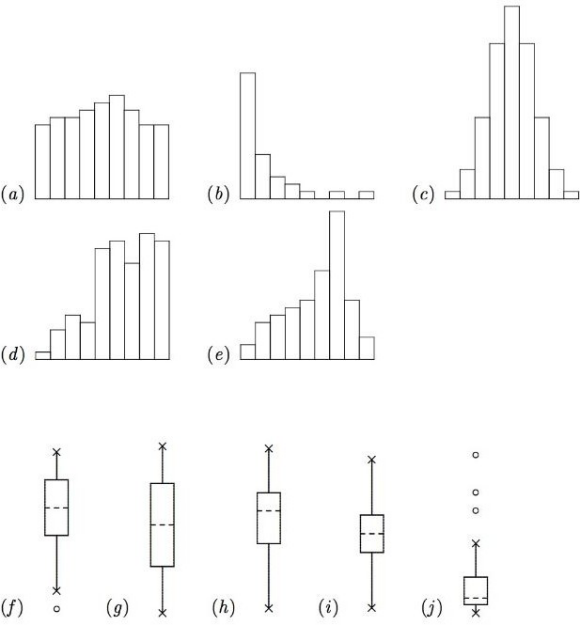